# ggplot2 histogram

Jeswin

5 October 2017

```r
library(ggplot2)
library(tidyr)
suppressMessages(library(dplyr))
```

**rep(x,times)** replicates the values in x.

If times consists of a single integer, the result consists of the whole input repeated this many times. If times is a vector of the same length as x (after replication by each), the result consists of x[1] repeated times[1] times, x[2] repeated times[2] times and so on.

```r
set.seed(1234)
df <- data.frame(
  sex = factor(rep(c('F','M'), each = 200)),
  weight = round(c(rnorm(200, mean = 55, sd = 5), rnorm(200, mean = 65, sd = 5)))
)
head(df)
```

```
##   sex weight
## 1   F     49
## 2   F     56
## 3   F     60
## 4   F     43
## 5   F     57
## 6   F     58
```

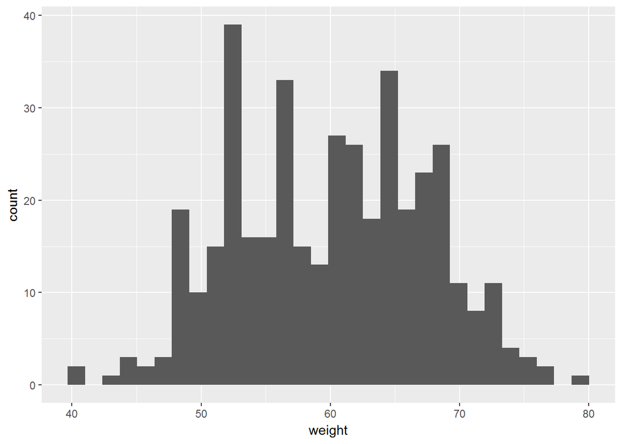

```r
# Basic histogram
ggplot(df, aes(x=weight)) + geom_histogram()
```

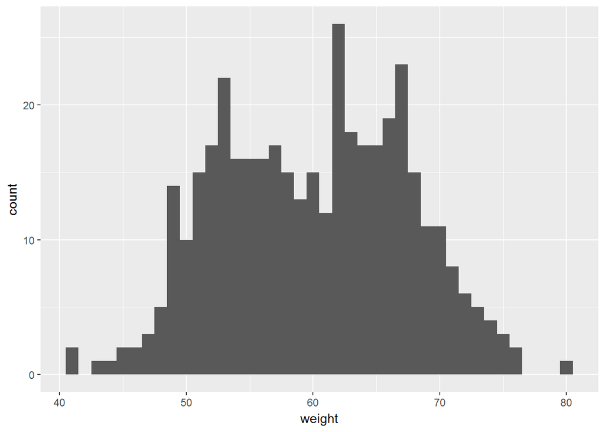

```r
# Change the width of bins
ggplot(df, aes(x=weight)) +
  geom_histogram(binwidth=1)
```

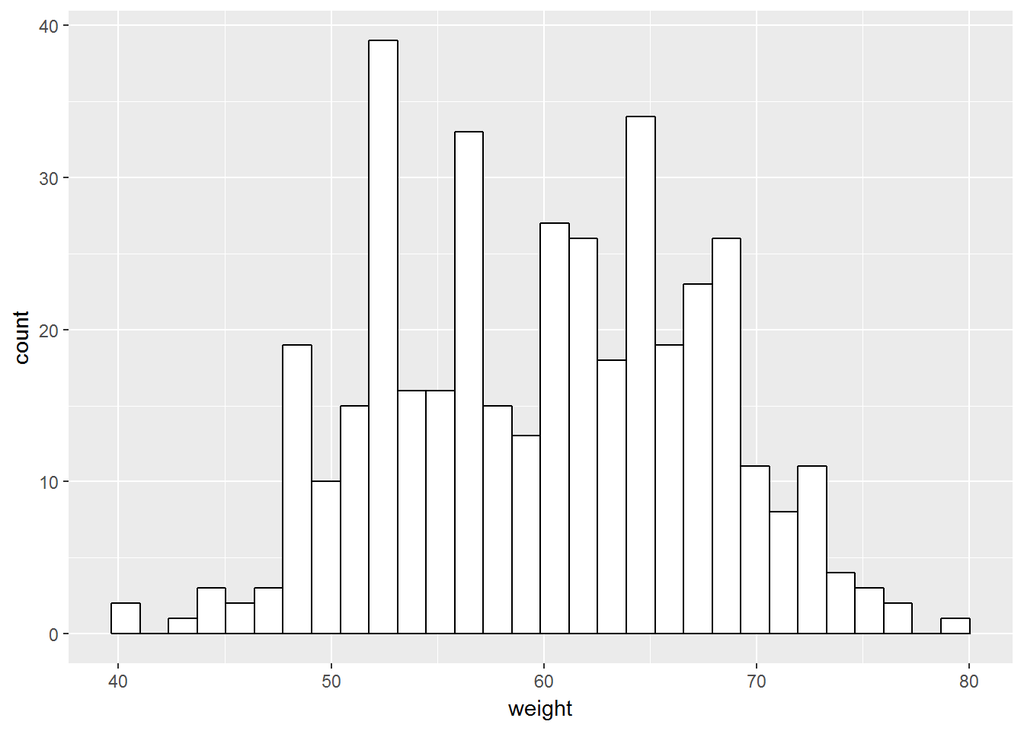

```r
# Change colors
p<-ggplot(df, aes(x=weight)) +
  geom_histogram(color="black", fill="white")
p
```

## Add mean line and density plot on the histogram

- The histogram is plotted with density instead of count on y-axis
- Overlay with transparent density plot. The value of alpha controls the level of transparency

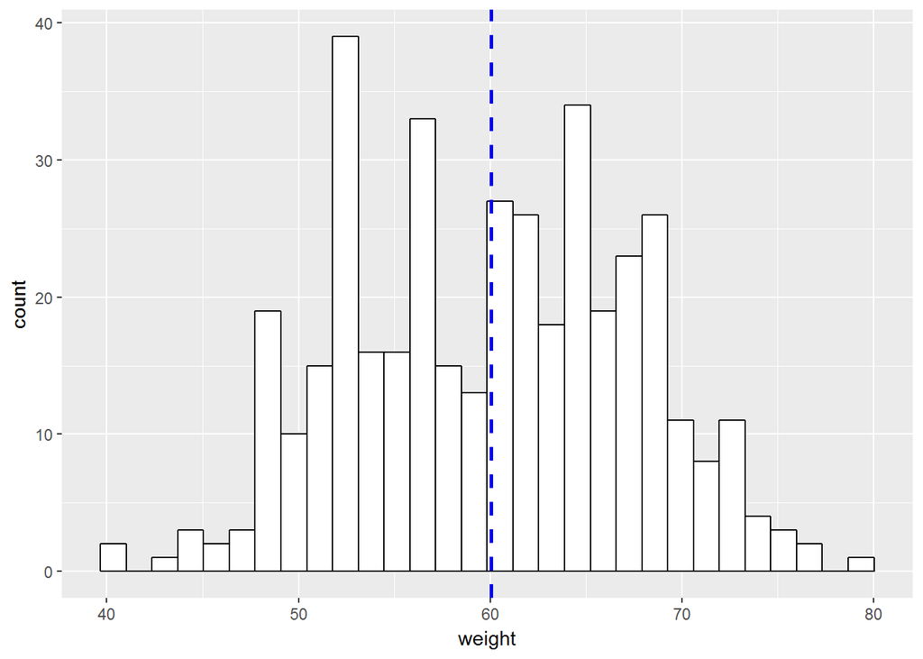

```r
# Add mean vline
p+geom_vline(aes(xintercept = mean(weight)), color = 'blue', linetype = 'dashed',size=1)
```

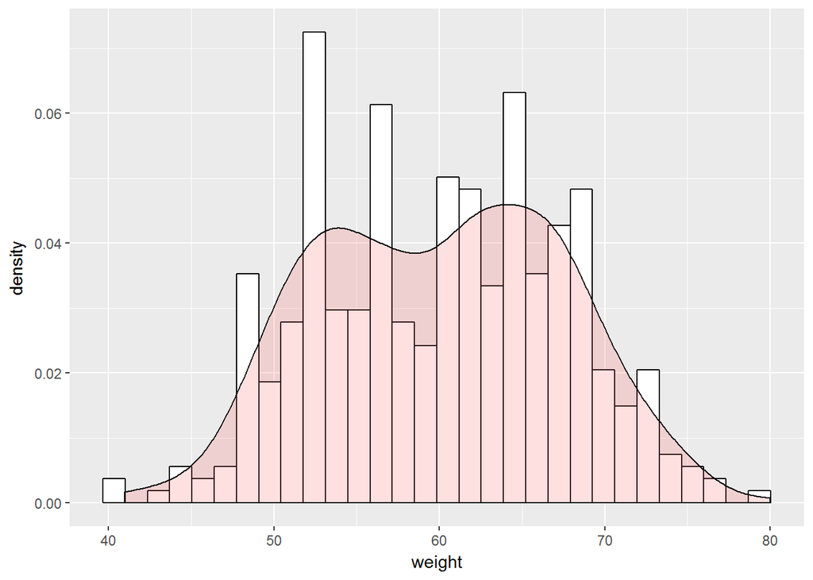

```r
# Histogrm with density plot
ggplot(df, aes(x=weight)) +
  geom_histogram(aes(y = ..density..), color = 'black', fill = 'white')+
  geom_density(alpha=0.2, fill = "#FF6666")
```

## Change histogram plot line types and colors

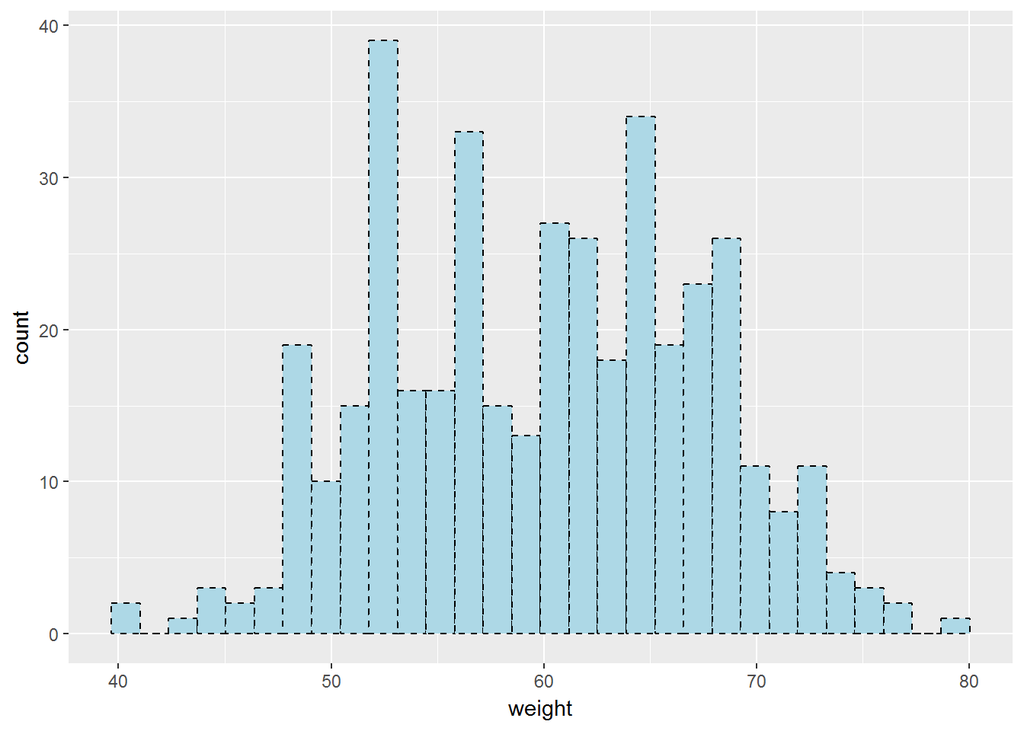

```r
# Change line type
ggplot(df, aes(x=weight))+
  geom_histogram(color="black", fill="lightblue",linetype="dashed")
```

## Change histogram plot colors by groups

### Calculate the mean of each group :

```r
mu <- df %>%
  group_by(sex)%>%
  summarise(mean = mean(weight))
mu
```

```
## # A tibble: 2 x 2
##      sex  mean
##   <fctr> <dbl>
## 1      F 54.70
## 2      M 65.36
```

### Change line colors

Histogram plot line colors can be automatically controlled by the levels of the variable sex.

```
Note that, you can change the position adjustment to use for overlapping points on the layer. Possible values for the argument
position are "identity", "stack", "dodge". Default value is "stack".
```

Here tried with the three positionj types.

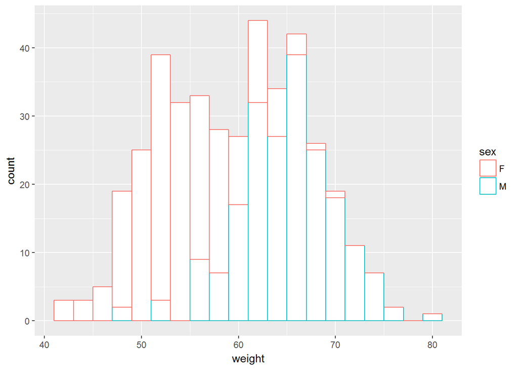

```r
# Change histogram plot line colors by groups
ggplot(df, aes(x=weight, color=sex)) +
  geom_histogram(fill="white", binwidth = 2)
```

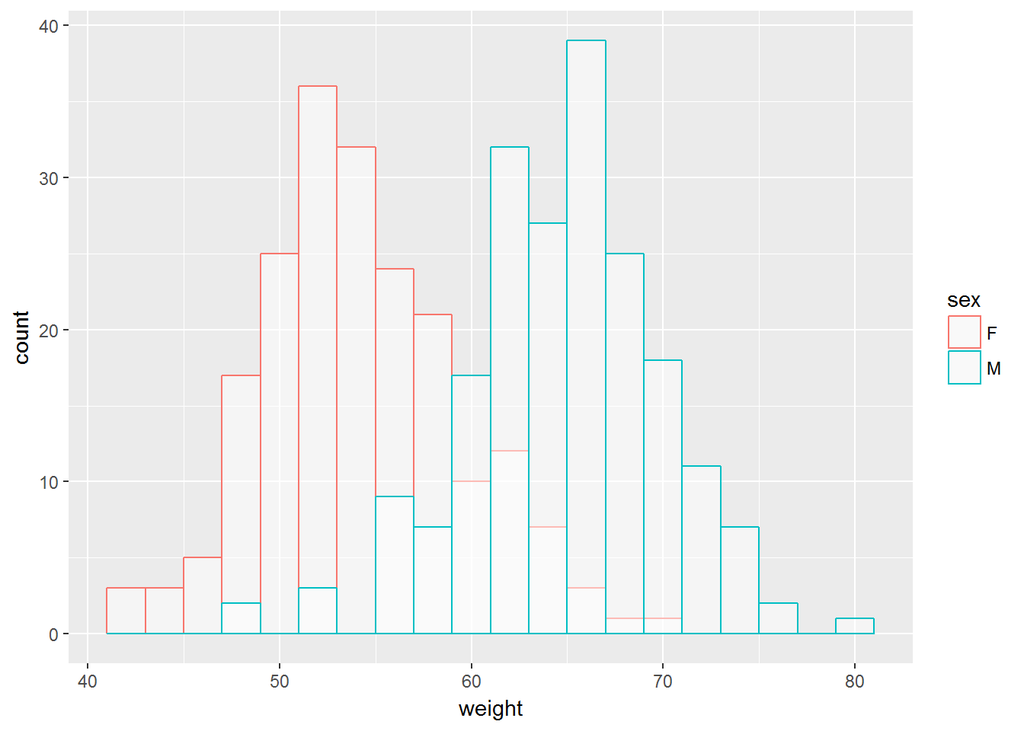

```r
# Overlaid histograms
ggplot(df, aes(x=weight, color=sex)) +
  geom_histogram(fill="white", alpha=0.5, position="identity", binwidth = 2)
```

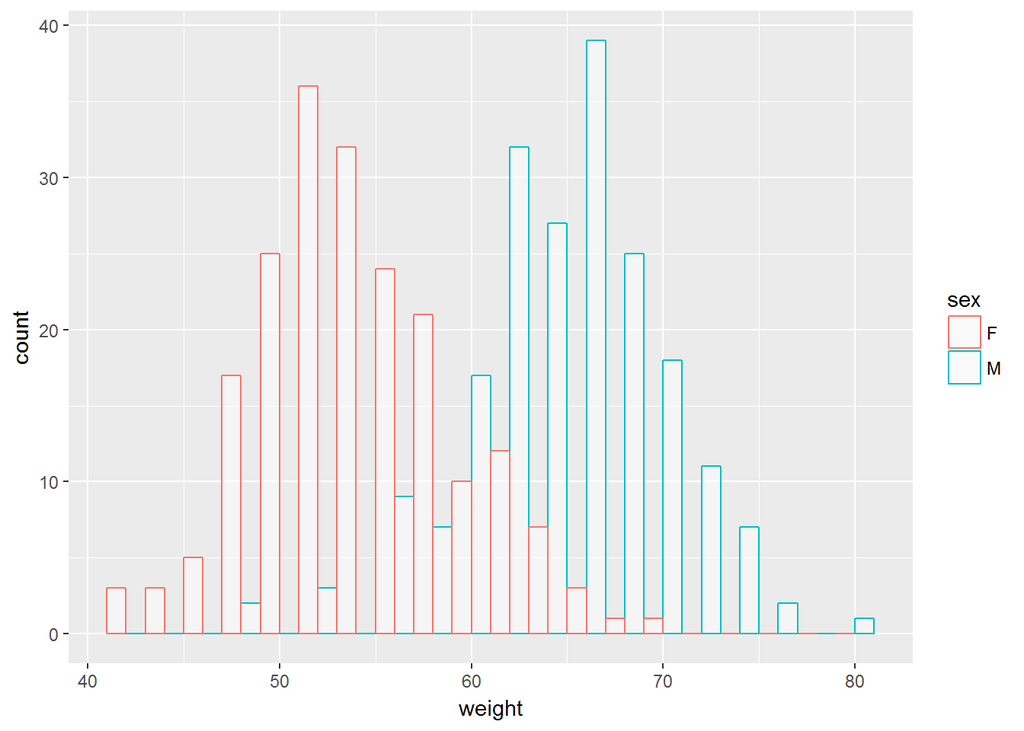

```r
# Overlaid histograms
ggplot(df, aes(x=weight, color=sex)) +
  geom_histogram(fill="white", alpha=0.5, position="dodge",binwidth = 2)
```

### # Interleaved histograms

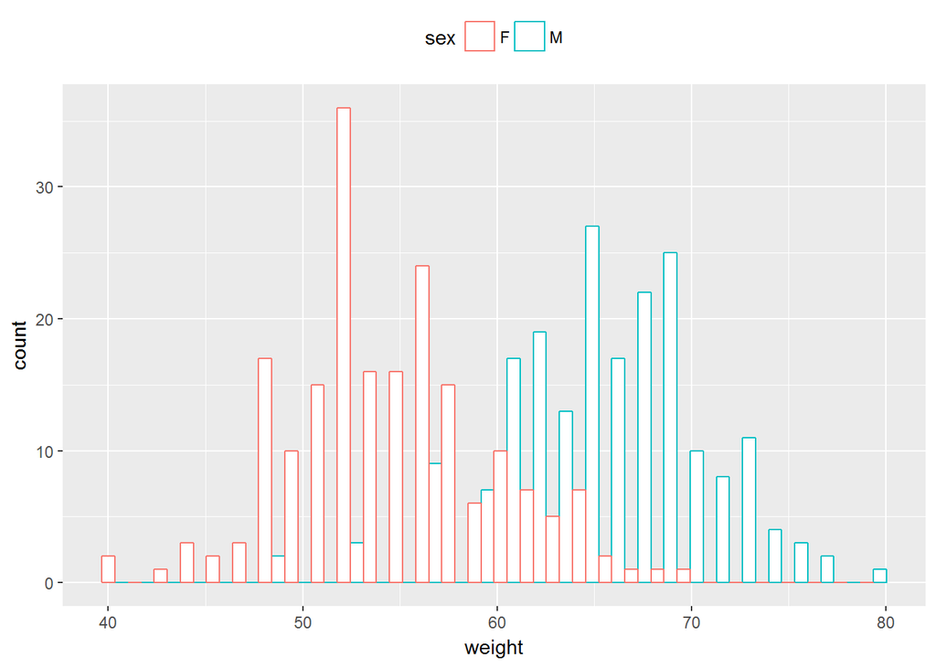

```r
# Interleaved histograms
ggplot(df, aes(x=weight, color=sex)) +
  geom_histogram(fill="white", position="dodge")+
  theme(legend.position="top")
```

##### Observe how the ggplot and geom_vline use different dataframes

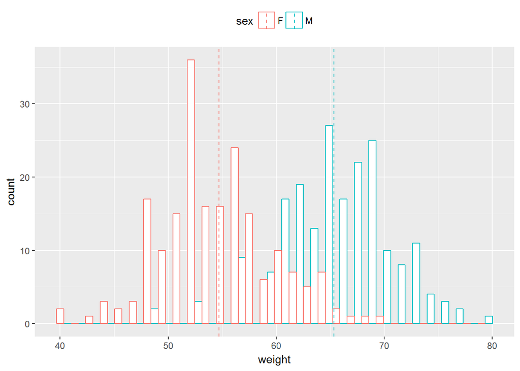

```r
# Add mean lines
p<-ggplot(df, aes(x=weight, color=sex)) +
  geom_histogram(fill="white", position="dodge")+
  geom_vline(data=mu, aes(xintercept=mean, color=sex),
             linetype="dashed")+
  theme(legend.position="top")
p
```

It is also possible to change manually histogram plot line colors using the functions :

- **scale_color_manual()** : to use custom colors
- **scale_color_brewer()** : to use color palettes from RColorBrewer package
- **scale_color_grey()** : to use grey color palettes

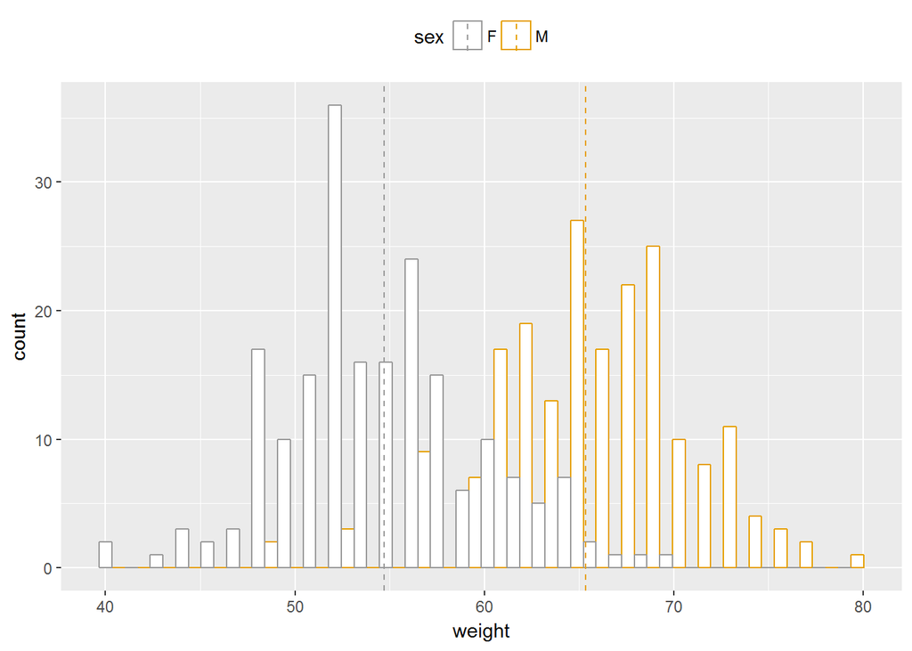

```r
# Use custom color palettes
p+scale_color_manual(values=c("#999999", "#E69F00", "#56B4E9"))
```

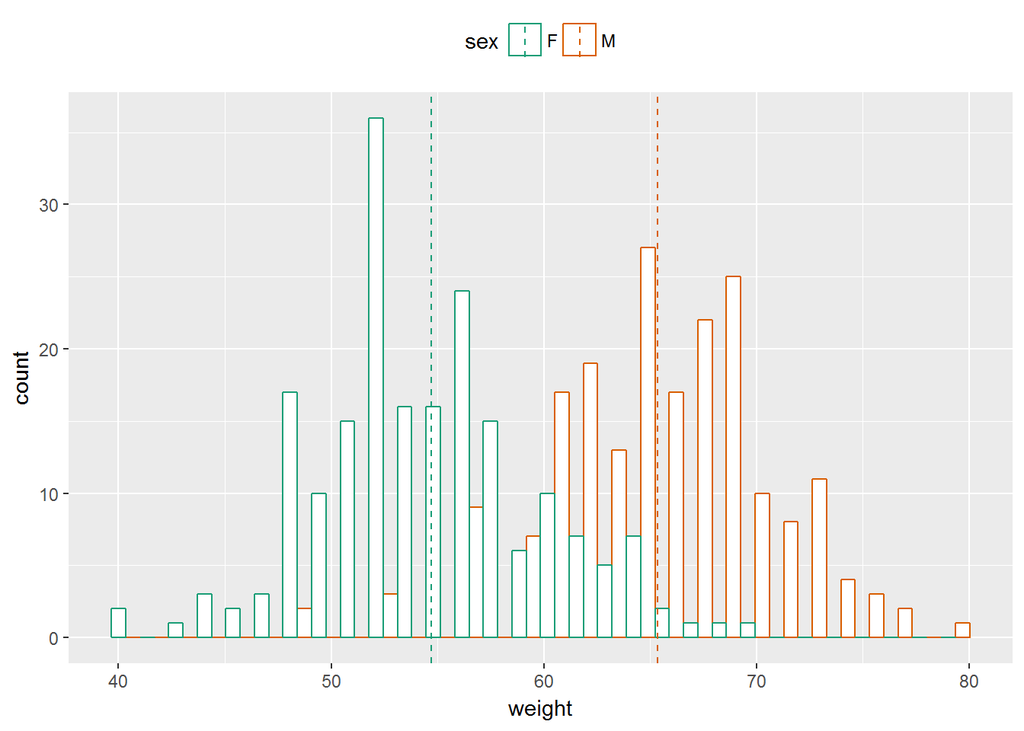

```r
# Use brewer color palettes
p+scale_color_brewer(palette="Dark2")
```

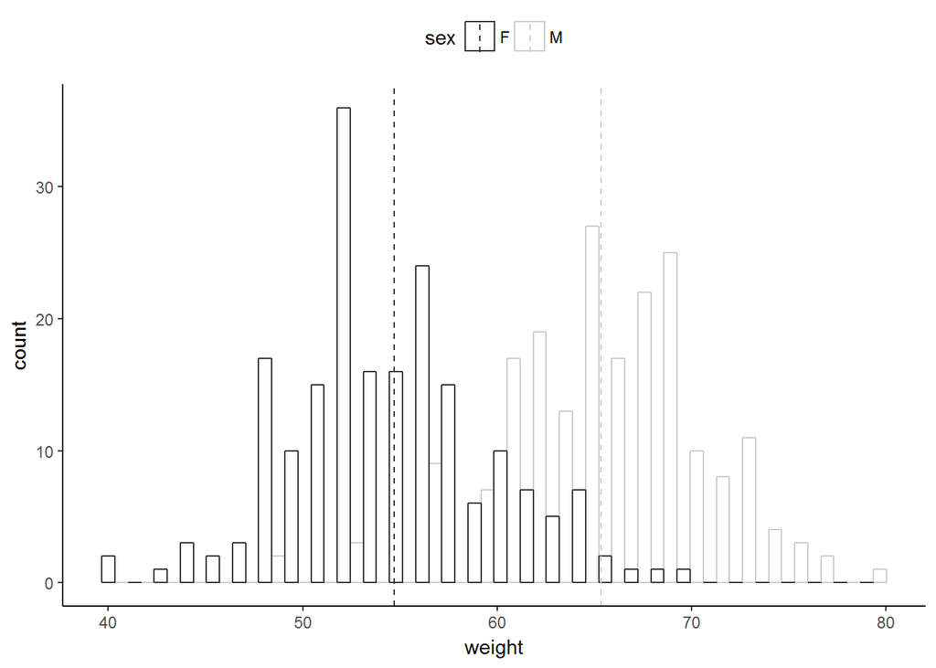

```r
# Use grey scale
p + scale_color_grey() + theme_classic() +
  theme(legend.position="top")
```

### Change fill colors

Histogram plot fill colors can be automatically controlled by the levels of sex:

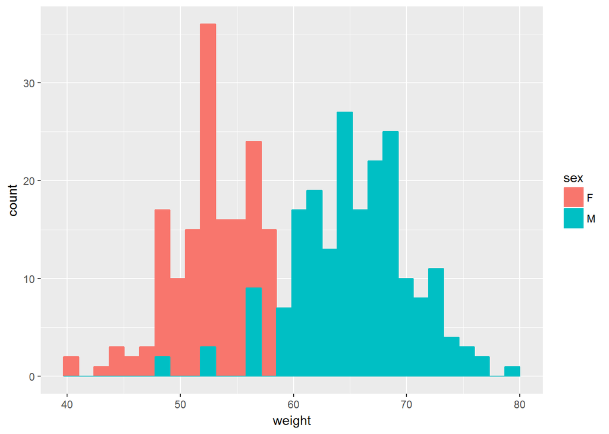

```r
# Change histogram plot fill colors by groups
ggplot(df, aes(x=weight, fill=sex, color=sex)) +
  geom_histogram(position="identity")
```

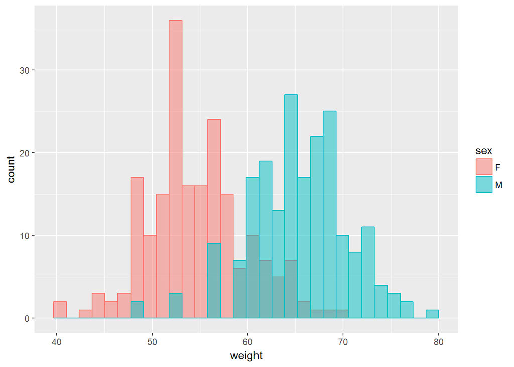

```r
p<-ggplot(df, aes(x=weight, fill=sex, color=sex)) +
  geom_histogram(position="identity", alpha=0.5)
p
```

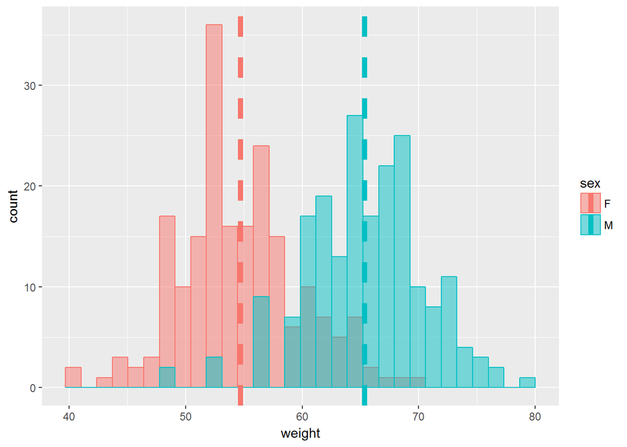

```r
# Add mean lines
p+geom_vline(data=mu, aes(xintercept=mean, color=sex),
             linetype="dashed", size=2)
```

Some plots remaining : Refer : *sthda.com ggplot2 essentials histogram*